# StarterNotebook

This is a simple starter notebook to help you get started with the hackathon

```python
# import libraries
import os
import random
import pandas as pd
import numpy as np

import matplotlib.pyplot as plt
import seaborn as sns

from sklearn.ensemble import RandomForestRegressor
from sklearn.model_selection import train_test_split
from sklearn.metrics import mean_squared_error

from datetime import datetime

%matplotlib inline
import warnings
warnings.filterwarnings('ignore')
```

```python
# Linear models
from sklearn.linear_model import (
    LinearRegression, Ridge, Lasso, ElasticNet,
    BayesianRidge, ARDRegression,
    HuberRegressor, RANSACRegressor, TheilSenRegressor,
    SGDRegressor,
    PoissonRegressor, GammaRegressor, TweedieRegressor
)

# Ensemble models
from sklearn.ensemble import (
    RandomForestRegressor, GradientBoostingRegressor,
    HistGradientBoostingRegressor, AdaBoostRegressor,
    BaggingRegressor, ExtraTreesRegressor,
    StackingRegressor, VotingRegressor
)

# Tree-based model
from sklearn.tree import DecisionTreeRegressor

# Support Vector Regression
from sklearn.svm import SVR, LinearSVR

# Nearest Neighbors
from sklearn.neighbors import KNeighborsRegressor, RadiusNeighborsRegressor

# Gaussian Process Regression
from sklearn.gaussian_process import GaussianProcessRegressor

# Neural Networks
from sklearn.neural_network import MLPRegressor
```

```python
# Set seed for reproducability
SEED = 2025
random.seed(SEED)
np.random.seed(SEED)
```

## Loading and previewing data

```python
DATA_PATH = 'data'
SUBMISSION_PATH = 'submissions'
# Load files
train = pd.read_csv(os.path.join(DATA_PATH, 'Train.csv'))
test = pd.read_csv(os.path.join(DATA_PATH, 'Test.csv'))
samplesubmission = pd.read_csv(os.path.join(SUBMISSION_PATH, 'SampleSubmission.csv'))
weather_df = pd.read_csv(os.path.join(DATA_PATH, 'Accra_weather.csv'), index_col=0)
variable_def = pd.read_csv(os.path.join(DATA_PATH, 'VariableDefinitions.csv'))
```

```python
variable_def
```

|  | Attribute | Description |
| --- | --- | --- |
| 0 | trip_id | Unique identifier for the trip |
| 1 | lcl_start_transporting_dt | Local date when the trip started |
| 2 | lcl_start_transporting_dttm | Local date and time when the trip started |
| 3 | lcl_order_finished_dttm | Local date and time when the trip ended |
| 4 | transporting_time_fact_mnt | Actual travel time in minutes |
| 5 | transporting_distance_fact_km | Actual travel distance in kilometers |
| 6 | str_distance_km | Straight-line distance in kilometers |
| 7 | origin_lat | Latitude of the starting point |
| 8 | origin_lon | Longitude of the starting point |
| 9 | destination_lat | Latitude of the destination point |
| 10 | destination_lon | Longitude of the destination point |
| 11 | lcl_date | Local date |
| 12 | lcl_datetime | Local date and time |
| 13 | precipitation_type | Type of precipitation |
| 14 | prev_hour_precipitation_mm | Precipitation in millimeters in the past hour |
| 15 | temperature_C | Temperature in degrees Celsius |

```python
train.head()
```

|  | trip_id | destination_lat | destination_lon | lcl_start_transporting_dt | lcl_start_transporting_dttm | origin_lat | origin_lon | str_distance_km | transporting_distance_fact_km | Target |
| --- | --- | --- | --- | --- | --- | --- | --- | --- | --- | --- |
| 0 | ID_S3BD1V9G53 | 5.630927 | -0.169211 | 2024-05-05 | 2024-05-05 09:56:32 | 5.630979 | -0.164760 | 0.529 | 0.850 | 2.18 |
| 1 | ID_ZJM7LMN65Q | 5.645044 | -0.156482 | 2024-05-21 | 2024-05-21 10:53:32 | 5.686892 | -0.118931 | 6.230 | 8.720 | 20.93 |
| 2 | ID_SZ3BP6V01V | 5.711156 | -0.141063 | 2024-05-05 | 2024-05-05 21:21:21 | 5.706008 | -0.164999 | 2.705 | 3.239 | 13.02 |
| 3 | ID_5IPHXDCMKF | 5.677497 | -0.183350 | 2024-05-26 | 2024-05-26 21:23:33 | 5.665943 | -0.182602 | 1.236 | 1.410 | 3.80 |
| 4 | ID_BYZEJ0B5RA | 5.601700 | -0.173589 | 2024-05-30 | 2024-05-30 14:02:13 | 5.565401 | -0.160919 | 4.312 | 6.553 | 17.23 |

```python
test.head()
```

|  | trip_id | destination_lat | destination_lon | lcl_start_transporting_dt | lcl_start_transporting_dttm | origin_lat | origin_lon | str_distance_km | transporting_distance_fact_km |
| --- | --- | --- | --- | --- | --- | --- | --- | --- | --- |
| 0 | ID_PV4QVE2H2X | 5.659192 | -0.128552 | 2024-05-28 | 2024-05-28 12:05:02 | 5.656207 | -0.134396 | 0.673 | 1.241 |
| 1 | ID_SUOBMO2E7V | 5.664648 | -0.143562 | 2024-05-07 | 2024-05-07 14:49:53 | 5.652780 | -0.153714 | 1.802 | 2.650 |
| 2 | ID_Q5KSL38U9B | 5.642269 | -0.152571 | 2024-05-18 | 2024-05-18 22:04:02 | 5.665573 | -0.126283 | 3.833 | 6.015 |
| 3 | ID_1G08NWYA35 | 5.695806 | -0.118942 | 2024-05-25 | 2024-05-25 05:18:49 | 5.678735 | -0.172577 | 6.219 | 7.987 |
| 4 | ID_H7IZ8JL8YT | 5.561824 | -0.199377 | 2024-05-29 | 2024-05-29 16:55:24 | 5.551920 | -0.196771 | 1.138 | 2.078 |

```python
samplesubmission.head()
```

|  | trip_id | Target |
| --- | --- | --- |
| 0 | ID_AH24RTKUMM | 0 |
| 1 | ID_1UH56FLC88 | 0 |
| 2 | ID_014VH4SGZI | 0 |
| 3 | ID_J8HIZ307LQ | 0 |
| 4 | ID_ER6CPWJQ17 | 0 |

```python
weather_df.head()
```

| lcl_date | lcl_datetime | precipitation_type | prev_hour_precipitation_mm | temperature_C |
| --- | --- | --- | --- | --- |
| 2024-05-01 | 2024-05-01 00:00:00 | Rain | 0.001907 | 28.54 |
| 2024-05-01 | 2024-05-01 01:00:00 | Rain | 0.002861 | 28.51 |
| 2024-05-01 | 2024-05-01 02:00:00 | Rain | 0.002861 | 28.51 |
| 2024-05-01 | 2024-05-01 03:00:00 | Rain | 0.000954 | 28.53 |
| 2024-05-01 | 2024-05-01 04:00:00 | Rain | 0.001907 | 28.60 |

```python
def extract_datetime_features(data, cols: list):
    df = data.copy()
    for col in cols:
        df[col] = pd.to_datetime(df[col])
        df[f'{col}_hour'] = df[col].dt.hour
        df[f'{col}_day'] = df[col].dt.day
        df[f'{col}_month'] = df[col].dt.month

    return df
```

```python
# extract datetime features
train = extract_datetime_features(train, ['lcl_start_transporting_dttm'])
test = extract_datetime_features(test, ['lcl_start_transporting_dttm'])
weather_df = extract_datetime_features(weather_df, ['lcl_datetime'])

# Preview train dataset
train.head()
```

|  | trip_id | destination_lat | destination_lon | lcl_start_transporting_dt | lcl_start_transporting_dttm | origin_lat | origin_lon | str_distance_km | transporting_distance_fact_km | Target | lcl_start_transporting_dttm_hour | lcl_start_transporting_dttm_day | lcl_start_transporting_dttm_month |
| --- | --- | --- | --- | --- | --- | --- | --- | --- | --- | --- | --- | --- | --- |
| 0 | ID_S3BD1V9G53 | 5.630927 | -0.169211 | 2024-05-05 | 2024-05-05 09:56:32 | 5.630979 | -0.164760 | 0.529 | 0.850 | 2.18 | 9 | 5 | 5 |
| 1 | ID_ZJM7LMN65Q | 5.645044 | -0.156482 | 2024-05-21 | 2024-05-21 10:53:32 | 5.686892 | -0.118931 | 6.230 | 8.720 | 20.93 | 10 | 21 | 5 |
| 2 | ID_SZ3BP6V01V | 5.711156 | -0.141063 | 2024-05-05 | 2024-05-05 21:21:21 | 5.706008 | -0.164999 | 2.705 | 3.239 | 13.02 | 21 | 5 | 5 |
| 3 | ID_5IPHXDCMKF | 5.677497 | -0.183350 | 2024-05-26 | 2024-05-26 21:23:33 | 5.665943 | -0.182602 | 1.236 | 1.410 | 3.80 | 21 | 26 | 5 |
| 4 | ID_BYZEJ0B5RA | 5.601700 | -0.173589 | 2024-05-30 | 2024-05-30 14:02:13 | 5.565401 | -0.160919 | 4.312 | 6.553 | 17.23 | 14 | 30 | 5 |

```python
# Preview test dataset
test.head()
```

|  | trip_id | destination_lat | destination_lon | lcl_start_transporting_dt | lcl_start_transporting_dttm | origin_lat | origin_lon | str_distance_km | transporting_distance_fact_km | lcl_start_transporting_dttm_hour | lcl_start_transporting_dttm_day | lcl_start_transporting_dttm_month |
| --- | --- | --- | --- | --- | --- | --- | --- | --- | --- | --- | --- | --- |
| 0 | ID_PV4QVE2H2X | 5.659192 | -0.128552 | 2024-05-28 | 2024-05-28 12:05:02 | 5.656207 | -0.134396 | 0.673 | 1.241 | 12 | 28 | 5 |
| 1 | ID_SUOBMO2E7V | 5.664648 | -0.143562 | 2024-05-07 | 2024-05-07 14:49:53 | 5.652780 | -0.153714 | 1.802 | 2.650 | 14 | 7 | 5 |
| 2 | ID_Q5KSL38U9B | 5.642269 | -0.152571 | 2024-05-18 | 2024-05-18 22:04:02 | 5.665573 | -0.126283 | 3.833 | 6.015 | 22 | 18 | 5 |
| 3 | ID_1G08NWYA35 | 5.695806 | -0.118942 | 2024-05-25 | 2024-05-25 05:18:49 | 5.678735 | -0.172577 | 6.219 | 7.987 | 5 | 25 | 5 |
| 4 | ID_H7IZ8JL8YT | 5.561824 | -0.199377 | 2024-05-29 | 2024-05-29 16:55:24 | 5.551920 | -0.196771 | 1.138 | 2.078 | 16 | 29 | 5 |

```python
# Preview sample submission file
samplesubmission.head()
```

|  | trip_id | Target |
| --- | --- | --- |
| 0 | ID_AH24RTKUMM | 0 |
| 1 | ID_1UH56FLC88 | 0 |
| 2 | ID_014VH4SGZI | 0 |
| 3 | ID_J8HIZ307LQ | 0 |
| 4 | ID_ER6CPWJQ17 | 0 |

```python
# Preview graph data
weather_df.head()
```

| lcl_date | lcl_datetime | precipitation_type | prev_hour_precipitation_mm | temperature_C | lcl_datetime_hour | lcl_datetime_day | lcl_datetime_month |
| --- | --- | --- | --- | --- | --- | --- | --- |
| 2024-05-01 | 2024-05-01 00:00:00 | Rain | 0.001907 | 28.54 | 0 | 1 | 5 |
| 2024-05-01 | 2024-05-01 01:00:00 | Rain | 0.002861 | 28.51 | 1 | 1 | 5 |
| 2024-05-01 | 2024-05-01 02:00:00 | Rain | 0.002861 | 28.51 | 2 | 1 | 5 |
| 2024-05-01 | 2024-05-01 03:00:00 | Rain | 0.000954 | 28.53 | 3 | 1 | 5 |
| 2024-05-01 | 2024-05-01 04:00:00 | Rain | 0.001907 | 28.60 | 4 | 1 | 5 |

```python
# Check size and shape of datasets
train.shape, test.shape, samplesubmission.shape
```

```
((57596, 13), (24684, 12), (24684, 2))
```

```python
# Train to test sets ratio
(test.shape[0]) / (train.shape[0] + test.shape[0])
```

```
0.3
```

## Statistical summaries

```python
# Train statistical summary
train.describe(include = 'number')  # could also do include = 'all' or 'object'
```

|  | destination_lat | destination_lon | origin_lat | origin_lon | str_distance_km | transporting_distance_fact_km | Target | lcl_start_transporting_dttm_hour | lcl_start_transporting_dttm_day | lcl_start_transporting_dttm_month |
| --- | --- | --- | --- | --- | --- | --- | --- | --- | --- | --- |
| count | 57596.000000 | 57596.000000 | 57596.000000 | 57596.000000 | 57596.000000 | 57596.000000 | 57596.000000 | 57596.000000 | 57596.000000 | 57596.000000 |
| mean | 5.644267 | -0.169131 | 5.644717 | -0.169566 | 1.856562 | 3.170373 | 10.084202 | 13.591465 | 16.342645 | 5.000122 |
| std | 0.044116 | 0.041993 | 0.043378 | 0.041983 | 1.564909 | 2.855521 | 8.902421 | 5.493301 | 8.883002 | 0.011024 |
| min | 5.526851 | -0.354872 | 5.527981 | -0.349419 | 0.000000 | 0.501000 | 1.020000 | 0.000000 | 1.000000 | 5.000000 |
| 25% | 5.622134 | -0.187408 | 5.622675 | -0.186448 | 0.934000 | 1.599000 | 5.270000 | 10.000000 | 9.000000 | 5.000000 |
| 50% | 5.656059 | -0.167765 | 5.657558 | -0.167834 | 1.447000 | 2.379000 | 7.710000 | 14.000000 | 16.000000 | 5.000000 |
| 75% | 5.675784 | -0.149920 | 5.675472 | -0.150483 | 2.245000 | 3.742000 | 12.030000 | 18.000000 | 24.000000 | 5.000000 |
| max | 5.754841 | -0.047629 | 5.752558 | -0.048585 | 18.120000 | 90.428000 | 585.930000 | 23.000000 | 31.000000 | 6.000000 |

Some insights from the above summary:

- The train data provided has 57 596 data points
- The average trip time is 10.08 mins
- The shortest trip took a 1.02 minute while the longest took 585.93 mins (possible outliers)

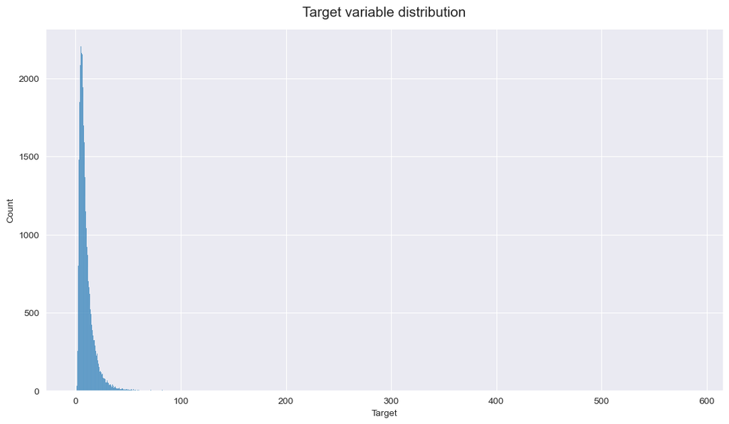

```
None
```

```
10.334243815626118
```

```python
# Target variable distribution
sns.set_style('darkgrid')
plt.figure(figsize = (13, 7))
sns.histplot(train.Target)
plt.title('Target variable distribution', y = 1.02, fontsize = 15)
display(plt.show(), train.Target.skew())
```

The target variable appears to be right skewed

## Outliers

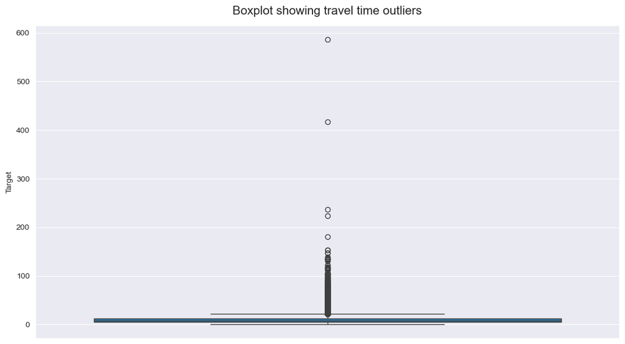

```python
# Plotting boxplot for travel time
sns.set_style('darkgrid')
plt.figure(figsize = (13, 7))
sns.boxplot(train.Target)
plt.title('Boxplot showing travel time outliers', y = 1.02, fontsize = 15)
plt.show()
```

Outliers are those data points which differ significantly from other observations present in given dataset.

Suggestions on how to handle outliers:

- Transforming the outliers by scaling - log transformation, box-cox transformation ...
- Dropping outliers
- Imputation by replacing outliers with mean, median ...

## Weather data

```python
weather_df.lcl_datetime.min(), weather_df.lcl_datetime.max()
```

```
(Timestamp('2024-05-01 00:00:00'), Timestamp('2024-05-31 23:00:00'))
```

```python
weather_df.describe(include='all')
```

|  | lcl_datetime | precipitation_type | prev_hour_precipitation_mm | temperature_C | lcl_datetime_hour | lcl_datetime_day | lcl_datetime_month |
| --- | --- | --- | --- | --- | --- | --- | --- |
| count | 744 | 744 | 744.000000 | 744.000000 | 744.000000 | 744.000000 | 744.0 |
| unique | NaN | 2 | NaN | NaN | NaN | NaN | NaN |
| top | NaN | Rain | NaN | NaN | NaN | NaN | NaN |
| freq | NaN | 682 | NaN | NaN | NaN | NaN | NaN |
| mean | 2024-05-16 11:29:59.999999744 | NaN | 0.151697 | 28.299825 | 11.500000 | 16.000000 | 5.0 |
| min | 2024-05-01 00:00:00 | NaN | 0.000000 | 25.920000 | 0.000000 | 1.000000 | 5.0 |
| 25% | 2024-05-08 17:45:00 | NaN | 0.000954 | 27.650000 | 5.750000 | 8.000000 | 5.0 |
| 50% | 2024-05-16 11:30:00 | NaN | 0.012398 | 28.400000 | 11.500000 | 16.000000 | 5.0 |
| 75% | 2024-05-24 05:15:00 | NaN | 0.076294 | 29.010000 | 17.250000 | 24.000000 | 5.0 |
| max | 2024-05-31 23:00:00 | NaN | 4.338264 | 30.490000 | 23.000000 | 31.000000 | 5.0 |
| std | NaN | NaN | 0.466693 | 0.968711 | 6.926843 | 8.950289 | 0.0 |

Some insights from the above summary:

- An average of 0.151mm of precipitation was recorded in May 2024
- Highest precipitation was 4.34mm
- Average temp in May was 28.30 deg Celcius with a range between 25.92 and 30.49 degrees Celcius

Let's merge the weather and trips data

```python
train.head()
```

|  | trip_id | destination_lat | destination_lon | lcl_start_transporting_dt | lcl_start_transporting_dttm | origin_lat | origin_lon | str_distance_km | transporting_distance_fact_km | Target | lcl_start_transporting_dttm_hour | lcl_start_transporting_dttm_day | lcl_start_transporting_dttm_month |
| --- | --- | --- | --- | --- | --- | --- | --- | --- | --- | --- | --- | --- | --- |
| 0 | ID_S3BD1V9G53 | 5.630927 | -0.169211 | 2024-05-05 | 2024-05-05 09:56:32 | 5.630979 | -0.164760 | 0.529 | 0.850 | 2.18 | 9 | 5 | 5 |
| 1 | ID_ZJM7LMN65Q | 5.645044 | -0.156482 | 2024-05-21 | 2024-05-21 10:53:32 | 5.686892 | -0.118931 | 6.230 | 8.720 | 20.93 | 10 | 21 | 5 |
| 2 | ID_SZ3BP6V01V | 5.711156 | -0.141063 | 2024-05-05 | 2024-05-05 21:21:21 | 5.706008 | -0.164999 | 2.705 | 3.239 | 13.02 | 21 | 5 | 5 |
| 3 | ID_5IPHXDCMKF | 5.677497 | -0.183350 | 2024-05-26 | 2024-05-26 21:23:33 | 5.665943 | -0.182602 | 1.236 | 1.410 | 3.80 | 21 | 26 | 5 |
| 4 | ID_BYZEJ0B5RA | 5.601700 | -0.173589 | 2024-05-30 | 2024-05-30 14:02:13 | 5.565401 | -0.160919 | 4.312 | 6.553 | 17.23 | 14 | 30 | 5 |

```python
# create day_hour variable to merge trips and weather data on
train['day_hour'] = train['lcl_start_transporting_dttm_day'].astype(str).str.split('.').str[0] +\
 '_' + train['lcl_start_transporting_dttm_hour'].astype(str).str.split('.').str[0]

test['day_hour'] = test['lcl_start_transporting_dttm_day'].astype(str).str.split('.').str[0] +\
 '_' + test['lcl_start_transporting_dttm_hour'].astype(str).str.split('.').str[0]

weather_df['day_hour'] = weather_df['lcl_datetime_day'].astype(str).str.split('.').str[0] +\
 '_' + weather_df['lcl_datetime_hour'].astype(str).str.split('.').str[0]
```

```python
train = train.merge(weather_df, on='day_hour', how='left')
test = test.merge(weather_df, on='day_hour', how='left')
```

```python
train.head()
```

|  | trip_id | destination_lat | destination_lon | lcl_start_transporting_dt | lcl_start_transporting_dttm | origin_lat | origin_lon | str_distance_km | transporting_distance_fact_km | Target | ... | lcl_start_transporting_dttm_day | lcl_start_transporting_dttm_month | day_hour | lcl_datetime | precipitation_type | prev_hour_precipitation_mm | temperature_C | lcl_datetime_hour | lcl_datetime_day | lcl_datetime_month |
| --- | --- | --- | --- | --- | --- | --- | --- | --- | --- | --- | --- | --- | --- | --- | --- | --- | --- | --- | --- | --- | --- |
| 0 | ID_S3BD1V9G53 | 5.630927 | -0.169211 | 2024-05-05 | 2024-05-05 09:56:32 | 5.630979 | -0.164760 | 0.529 | 0.850 | 2.18 | ... | 5 | 5 | 5_9 | 2024-05-05 09:00:00 | Rain | 0.012875 | 28.74 | 9 | 5 | 5 |
| 1 | ID_ZJM7LMN65Q | 5.645044 | -0.156482 | 2024-05-21 | 2024-05-21 10:53:32 | 5.686892 | -0.118931 | 6.230 | 8.720 | 20.93 | ... | 21 | 5 | 21_10 | 2024-05-21 10:00:00 | Rain | 0.001907 | 29.32 | 10 | 21 | 5 |
| 2 | ID_SZ3BP6V01V | 5.711156 | -0.141063 | 2024-05-05 | 2024-05-05 21:21:21 | 5.706008 | -0.164999 | 2.705 | 3.239 | 13.02 | ... | 5 | 5 | 5_21 | 2024-05-05 21:00:00 | Rain | 0.001907 | 29.54 | 21 | 5 | 5 |
| 3 | ID_5IPHXDCMKF | 5.677497 | -0.183350 | 2024-05-26 | 2024-05-26 21:23:33 | 5.665943 | -0.182602 | 1.236 | 1.410 | 3.80 | ... | 26 | 5 | 26_21 | 2024-05-26 21:00:00 | No precipitation | 0.000000 | 28.49 | 21 | 26 | 5 |
| 4 | ID_BYZEJ0B5RA | 5.601700 | -0.173589 | 2024-05-30 | 2024-05-30 14:02:13 | 5.565401 | -0.160919 | 4.312 | 6.553 | 17.23 | ... | 30 | 5 | 30_14 | 2024-05-30 14:00:00 | No precipitation | 0.019073 | 29.38 | 14 | 30 | 5 |

5 rows × 21 columns

```python
test.head()
```

|  | trip_id | destination_lat | destination_lon | lcl_start_transporting_dt | lcl_start_transporting_dttm | origin_lat | origin_lon | str_distance_km | transporting_distance_fact_km | lcl_start_transporting_dttm_hour | lcl_start_transporting_dttm_day | lcl_start_transporting_dttm_month | day_hour | lcl_datetime | precipitation_type | prev_hour_precipitation_mm | temperature_C | lcl_datetime_hour | lcl_datetime_day | lcl_datetime_month |
| --- | --- | --- | --- | --- | --- | --- | --- | --- | --- | --- | --- | --- | --- | --- | --- | --- | --- | --- | --- | --- |
| 0 | ID_PV4QVE2H2X | 5.659192 | -0.128552 | 2024-05-28 | 2024-05-28 12:05:02 | 5.656207 | -0.134396 | 0.673 | 1.241 | 12 | 28 | 5 | 28_12 | 2024-05-28 12:00:00 | Rain | 0.000954 | 29.65 | 12 | 28 | 5 |
| 1 | ID_SUOBMO2E7V | 5.664648 | -0.143562 | 2024-05-07 | 2024-05-07 14:49:53 | 5.652780 | -0.153714 | 1.802 | 2.650 | 14 | 7 | 5 | 7_14 | 2024-05-07 14:00:00 | Rain | 0.002861 | 28.64 | 14 | 7 | 5 |
| 2 | ID_Q5KSL38U9B | 5.642269 | -0.152571 | 2024-05-18 | 2024-05-18 22:04:02 | 5.665573 | -0.126283 | 3.833 | 6.015 | 22 | 18 | 5 | 18_22 | 2024-05-18 22:00:00 | No precipitation | 0.000000 | 28.58 | 22 | 18 | 5 |
| 3 | ID_1G08NWYA35 | 5.695806 | -0.118942 | 2024-05-25 | 2024-05-25 05:18:49 | 5.678735 | -0.172577 | 6.219 | 7.987 | 5 | 25 | 5 | 25_5 | 2024-05-25 05:00:00 | Rain | 1.291275 | 26.89 | 5 | 25 | 5 |
| 4 | ID_H7IZ8JL8YT | 5.561824 | -0.199377 | 2024-05-29 | 2024-05-29 16:55:24 | 5.551920 | -0.196771 | 1.138 | 2.078 | 16 | 29 | 5 | 29_16 | 2024-05-29 16:00:00 | Rain | 0.000000 | 29.24 | 16 | 29 | 5 |

## Missing values and duplicates

```python
# Check for missing values
train.isnull().sum().any(), test.isnull().sum().any()
```

```
(False, False)
```

Suggestions on how to handle missing values:

- Fill in missing values with mode, mean, median..
- Drop Missing datapoints with missing values
- Fill in with a large number e.g -999999

```python
# Check for duplicates
train.duplicated().any(), test.duplicated().any()
```

```
(False, False)
```

## Correlations

```python
# Top 20 correlated features to the target
top20_corrs = abs(train.select_dtypes(include='number').corr()['Target']).sort_values(ascending = False).head(20)
top20_corrs
```

```
Target                               1.000000
transporting_distance_fact_km        0.831081
str_distance_km                      0.455688
origin_lon                           0.037094
destination_lon                      0.026450
lcl_start_transporting_dttm_hour     0.024966
lcl_datetime_hour                    0.024966
origin_lat                           0.017035
lcl_start_transporting_dttm_day      0.011372
lcl_datetime_day                     0.011372
temperature_C                        0.004476
prev_hour_precipitation_mm           0.003572
destination_lat                      0.003378
lcl_start_transporting_dttm_month    0.002502
lcl_datetime_month                        NaN
Name: Target, dtype: float64
```

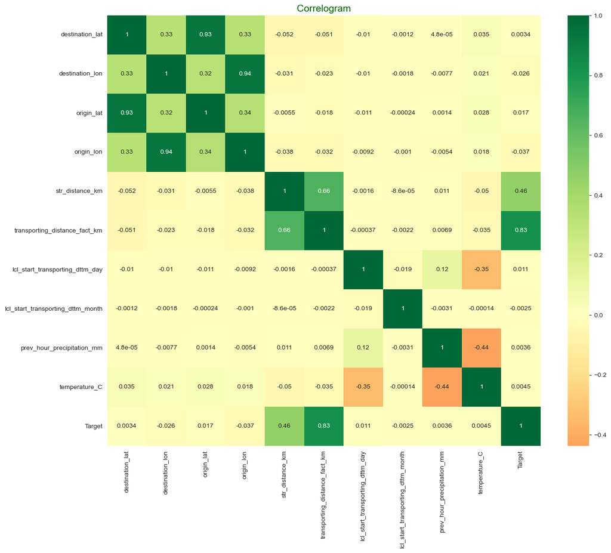

```python
cols = ['destination_lat','destination_lon','origin_lat','origin_lon',
        'str_distance_km','transporting_distance_fact_km', 'lcl_start_transporting_dttm_day',
        'lcl_start_transporting_dttm_month', 'prev_hour_precipitation_mm', 'temperature_C', 'Target']

# Plotting a heatmap to show correlations between variables
corr = train[cols].corr()
plt.figure(figsize = (15, 12))
sns.heatmap(corr, cmap='RdYlGn', annot = True, center = 0)
plt.title('Correlogram', fontsize = 15, color = 'darkgreen')
plt.show()
```

```python
# # Linear models
# from sklearn.linear_model import (
#     LinearRegression, Ridge, Lasso, ElasticNet,
#     BayesianRidge, ARDRegression,
#     HuberRegressor, RANSACRegressor, TheilSenRegressor,
#     SGDRegressor,
#     PoissonRegressor, GammaRegressor, TweedieRegressor
# )

# # Ensemble models
# from sklearn.ensemble import (
#     RandomForestRegressor, GradientBoostingRegressor,
#     HistGradientBoostingRegressor, AdaBoostRegressor,
#     BaggingRegressor, ExtraTreesRegressor,
#     StackingRegressor, VotingRegressor
# )

# # Tree-based model
# from sklearn.tree import DecisionTreeRegressor

# # Support Vector Regression
# from sklearn.svm import SVR, LinearSVR

# # Nearest Neighbors
# from sklearn.neighbors import KNeighborsRegressor, RadiusNeighborsRegressor

# # Gaussian Process Regression
# from sklearn.gaussian_process import GaussianProcessRegressor

# # Neural Networks
# from sklearn.neural_network import MLPRegressor
```

## Modelling

```python
# Selecting the independent variables and the target variable
feature_cols = ['str_distance_km', 'temperature_C','transporting_distance_fact_km',
           'lcl_start_transporting_dttm_day', 'prev_hour_precipitation_mm']
X = train[feature_cols].fillna(0)
y = train.Target

# Splitting the data into training and testing sets
X_train, X_test, y_train, y_test = train_test_split(X, y, test_size = 0.05, random_state = SEED)

# Instantiating the model
# clf = LinearRegression(n_jobs=-1, fit_intercept=True, copy_X=True)
clf = MLPRegressor()
# clf = RandomForestRegressor(random_state = SEED, n_jobs=-1)
clf.fit(X_train, y_train)

# Making predictions
y_pred = clf.predict(X_test)

# Measuring the accuracy of the model
print(f'RMSE Score: {np.sqrt(mean_squared_error(y_test, y_pred))}')
```

```
RMSE Score: 4.052090596561878
```

```python
# Feature importance
impo_df = pd.DataFrame({'feature': X.columns, 'importance': clf.feature_importances_}).set_index('feature').sort_values(by = 'importance', ascending = False)
impo_df = impo_df[:12].sort_values(by = 'importance', ascending = True)
impo_df.plot(kind = 'barh', figsize = (10, 10))
plt.legend(loc = 'center right')
plt.title('Bar chart showing feature importance', fontsize = 14)
plt.xlabel('Features', fontsize = 12)
plt.show()
```

[output not shown]

## Making predictions of the test set and creating a submission file

```python
# Make prediction on the test set
test_df = test[feature_cols].fillna(0)
predictions = clf.predict(test_df)

# # Create a submission file
sub_file = pd.DataFrame({'trip_id': test.trip_id, 'Target': predictions})
sub_file.head()
```

|  | trip_id | Target |
| --- | --- | --- |
| 0 | ID_PV4QVE2H2X | 5.905152 |
| 1 | ID_SUOBMO2E7V | 8.667877 |
| 2 | ID_Q5KSL38U9B | 17.788972 |
| 3 | ID_1G08NWYA35 | 19.006009 |
| 4 | ID_H7IZ8JL8YT | 7.950226 |

```python
# Create file
timestamp = datetime.now().strftime("%Y%m%d_%H%M%S")
filename = f"MLPRegressor{timestamp}.csv"
sub_file.to_csv("submissions/"+filename, index = False)
```

# NEURAL NETWORK

```python
# !pip install tensorflow
```

[output not shown]

```python
import tensorflow as tf
from tensorflow.keras import layers, models
from sklearn.preprocessing import StandardScaler

# Enhanced feature engineering with proper handling of edge cases
def create_enhanced_features(df):
    df = df.copy()

    # Distance ratio (actual vs straight-line) - handle division by zero
    df['distance_ratio'] = np.where(
        df['str_distance_km'] > 0,
        df['transporting_distance_fact_km'] / df['str_distance_km'],
        1.0  # Default ratio when straight-line distance is 0
    )

    # Cap extreme values to prevent overflow
    df['distance_ratio'] = np.clip(df['distance_ratio'], 0, 10)  # Reasonable upper bound

    # Time-based features
    df['hour_sin'] = np.sin(2 * np.pi * df['lcl_start_transporting_dttm_hour'] / 24)
    df['hour_cos'] = np.cos(2 * np.pi * df['lcl_start_transporting_dttm_hour'] / 24)

    # Rush hour indicator
    df['rush_hour'] = ((df['lcl_start_transporting_dttm_hour'] >= 7) &
                       (df['lcl_start_transporting_dttm_hour'] <= 9) |
                       (df['lcl_start_transporting_dttm_hour'] >= 17) &
                       (df['lcl_start_transporting_dttm_hour'] <= 19)).astype(int)

    return df

# Enhanced feature set
enhanced_features = [
    'str_distance_km', 'transporting_distance_fact_km', 'distance_ratio',
    'origin_lat', 'origin_lon', 'destination_lat', 'destination_lon',
    'hour_sin', 'hour_cos', 'rush_hour',
    'lcl_start_transporting_dttm_day', 'temperature_C', 'prev_hour_precipitation_mm'
]

# Prepare data
train_enhanced = create_enhanced_features(train)
test_enhanced = create_enhanced_features(test)

X_enhanced = train_enhanced[enhanced_features].fillna(0)
y_enhanced = train_enhanced['Target']

# Additional check for infinite or NaN values
print("Checking for infinite or NaN values:")
print(f"Infinite values: {np.isinf(X_enhanced).sum().sum()}")
print(f"NaN values: {np.isnan(X_enhanced).sum().sum()}")

# Replace any remaining infinite values with 0
X_enhanced = X_enhanced.replace([np.inf, -np.inf], 0)

# Scale features
scaler = StandardScaler()
X_scaled = scaler.fit_transform(X_enhanced)

# Additional check after scaling
print(f"After scaling - Infinite values: {np.isinf(X_scaled).sum()}")
print(f"After scaling - NaN values: {np.isnan(X_scaled).sum()}")

# Split data
X_train_tf, X_val_tf, y_train_tf, y_val_tf = train_test_split(
    X_scaled, y_enhanced, test_size=0.2, random_state=SEED
)

# Build and train model
tf_model = build_tf_model(X_scaled.shape[1])

# Early stopping and model checkpointing
callbacks = [
    tf.keras.callbacks.EarlyStopping(patience=20, restore_best_weights=True),
    tf.keras.callbacks.ReduceLROnPlateau(factor=0.5, patience=10)
]

history = tf_model.fit(
    X_train_tf, y_train_tf,
    validation_data=(X_val_tf, y_val_tf),
    epochs=200,
    batch_size=256,
    callbacks=callbacks,
    verbose=1
)

# Evaluate
val_predictions = tf_model.predict(X_val_tf)
tf_rmse = np.sqrt(mean_squared_error(y_val_tf, val_predictions))
print(f'TensorFlow NN RMSE: {tf_rmse:.4f}')
```

[output not shown]

[output cut: 18 more lines]

```
180/180 ━━━━━━━━━━━━━━━━━━━━ 0s 1ms/step - loss: 23.3303 - mae: 2.7505 - val_loss: 17.0067 - val_mae: 2.2963 - learning_rate: 5.0000e-04
180/180 ━━━━━━━━━━━━━━━━━━━━ 0s 1ms/step - loss: 24.6933 - mae: 2.7420 - val_loss: 16.7812 - val_mae: 2.2930 - learning_rate: 5.0000e-04
180/180 ━━━━━━━━━━━━━━━━━━━━ 0s 2ms/step - loss: 22.6195 - mae: 2.7293 - val_loss: 17.3222 - val_mae: 2.3032 - learning_rate: 5.0000e-04
180/180 ━━━━━━━━━━━━━━━━━━━━ 0s 2ms/step - loss: 23.0935 - mae: 2.7339 - val_loss: 17.5199 - val_mae: 2.2939 - learning_rate: 2.5000e-04
180/180 ━━━━━━━━━━━━━━━━━━━━ 0s 1ms/step - loss: 26.5443 - mae: 2.7279 - val_loss: 17.2041 - val_mae: 2.2942 - learning_rate: 2.5000e-04
180/180 ━━━━━━━━━━━━━━━━━━━━ 0s 1ms/step - loss: 22.4115 - mae: 2.7266 - val_loss: 17.0361 - val_mae: 2.2875 - learning_rate: 2.5000e-04
180/180 ━━━━━━━━━━━━━━━━━━━━ 0s 1ms/step - loss: 23.5523 - mae: 2.6942 - val_loss: 16.8396 - val_mae: 2.2802 - learning_rate: 2.5000e-04
180/180 ━━━━━━━━━━━━━━━━━━━━ 0s 1ms/step - loss: 22.3720 - mae: 2.7056 - val_loss: 17.3641 - val_mae: 2.2924 - learning_rate: 2.5000e-04
180/180 ━━━━━━━━━━━━━━━━━━━━ 0s 1ms/step - loss: 21.5024 - mae: 2.7152 - val_loss: 17.5500 - val_mae: 2.2911 - learning_rate: 2.5000e-04
180/180 ━━━━━━━━━━━━━━━━━━━━ 0s 1ms/step - loss: 31.1735 - mae: 2.7573 - val_loss: 17.1153 - val_mae: 2.2877 - learning_rate: 2.5000e-04
180/180 ━━━━━━━━━━━━━━━━━━━━ 0s 1ms/step - loss: 24.7678 - mae: 2.7257 - val_loss: 16.9299 - val_mae: 2.2780 - learning_rate: 2.5000e-04
180/180 ━━━━━━━━━━━━━━━━━━━━ 0s 1ms/step - loss: 24.9480 - mae: 2.7381 - val_loss: 16.5912 - val_mae: 2.2766 - learning_rate: 2.5000e-04
180/180 ━━━━━━━━━━━━━━━━━━━━ 0s 1ms/step - loss: 23.5394 - mae: 2.7109 - val_loss: 16.7088 - val_mae: 2.2814 - learning_rate: 2.5000e-04
360/360 ━━━━━━━━━━━━━━━━━━━━ 0s 227us/step
TensorFlow NN RMSE: 4.0415
```

```python
# Make predictions on test set using TensorFlow model
test_enhanced_features = test_enhanced[enhanced_features].fillna(0)

# Replace any infinite values in test set
test_enhanced_features = test_enhanced_features.replace([np.inf, -np.inf], 0)

# Scale test features using the same scaler fitted on training data
test_scaled = scaler.transform(test_enhanced_features)

# Make predictions
test_predictions = tf_model.predict(test_scaled)

# Flatten predictions (remove extra dimension)
test_predictions = test_predictions.flatten()

# Create submission dataframe
submission = pd.DataFrame({
    'trip_id': test['trip_id'],
    'Target': test_predictions
})

# Preview the submission
print("Submission preview:")
print(submission.head())
print(f"\nSubmission shape: {submission.shape}")
print(f"Target predictions range: {test_predictions.min():.4f} to {test_predictions.max():.4f}")

# Create submission file with timestamp
timestamp = datetime.now().strftime("%Y%m%d_%H%M%S")
filename = f"TensorFlow_NN_{timestamp}.csv"
filepath = os.path.join(SUBMISSION_PATH, filename)

submission.to_csv(filepath, index=False)
print(f"\nSubmission file saved as: {filename}")
```

```
772/772 ━━━━━━━━━━━━━━━━━━━━ 0s 388us/step
Submission preview:
         trip_id     Target
0  ID_PV4QVE2H2X   3.711416
1  ID_SUOBMO2E7V   7.548671
2  ID_Q5KSL38U9B  13.500937
3  ID_1G08NWYA35  16.733585
4  ID_H7IZ8JL8YT   6.583237

Submission shape: (24684, 2)
Target predictions range: 2.3767 to 325.3144

Submission file saved as: TensorFlow_NN_20250705_122257.csv
```

```python
# Random Forest with Enhanced Features - Complete Pipeline

# Enhanced feature engineering with proper handling of edge cases
def create_enhanced_features(df):
    df = df.copy()

    # Distance ratio (actual vs straight-line) - handle division by zero
    df['distance_ratio'] = np.where(
        df['str_distance_km'] > 0,
        df['transporting_distance_fact_km'] / df['str_distance_km'],
        1.0  # Default ratio when straight-line distance is 0
    )

    # Cap extreme values to prevent overflow
    df['distance_ratio'] = np.clip(df['distance_ratio'], 0, 10)  # Reasonable upper bound

    # Time-based features
    df['hour_sin'] = np.sin(2 * np.pi * df['lcl_start_transporting_dttm_hour'] / 24)
    df['hour_cos'] = np.cos(2 * np.pi * df['lcl_start_transporting_dttm_hour'] / 24)

    # Rush hour indicator
    df['rush_hour'] = ((df['lcl_start_transporting_dttm_hour'] >= 7) &
                       (df['lcl_start_transporting_dttm_hour'] <= 9) |
                       (df['lcl_start_transporting_dttm_hour'] >= 17) &
                       (df['lcl_start_transporting_dttm_hour'] <= 19)).astype(int)

    return df

# Enhanced feature set
enhanced_features = [
    'str_distance_km', 'transporting_distance_fact_km', 'distance_ratio',
    'origin_lat', 'origin_lon', 'destination_lat', 'destination_lon',
    'hour_sin', 'hour_cos', 'rush_hour',
    'lcl_start_transporting_dttm_day', 'temperature_C', 'prev_hour_precipitation_mm'
]

# Prepare enhanced training data
train_enhanced = create_enhanced_features(train)
test_enhanced = create_enhanced_features(test)

X_enhanced = train_enhanced[enhanced_features].fillna(0)
y_enhanced = train_enhanced['Target']

# Replace any infinite values
X_enhanced = X_enhanced.replace([np.inf, -np.inf], 0)

print(f"Enhanced feature set shape: {X_enhanced.shape}")
print(f"Features: {enhanced_features}")

# Split data for validation
X_train_rf, X_val_rf, y_train_rf, y_val_rf = train_test_split(
    X_enhanced, y_enhanced, test_size=0.2, random_state=SEED
)

# Train Random Forest with enhanced features
rf_model = KNeighborsRegressor()

print("Training Random Forest model...")
rf_model.fit(X_train_rf, y_train_rf)

# Evaluate on validation set
val_predictions = rf_model.predict(X_val_rf)
rf_rmse = np.sqrt(mean_squared_error(y_val_rf, val_predictions))
print(f'Random Forest RMSE: {rf_rmse:.4f}')

# Feature importance
# feature_importance = pd.DataFrame({
#     'feature': enhanced_features,
#     'importance': rf_model.feature_importances_
# }).sort_values('importance', ascending=False)

# print("\nTop 10 Most Important Features:")
# print(feature_importance.head(10))

# Prepare test data and make predictions
test_enhanced_features = test_enhanced[enhanced_features].fillna(0)
test_enhanced_features = test_enhanced_features.replace([np.inf, -np.inf], 0)

# Make predictions on test set
test_predictions = rf_model.predict(test_enhanced_features)

# Create submission dataframe
submission = pd.DataFrame({
    'trip_id': test['trip_id'],
    'Target': test_predictions
})

# Preview the submission
print("\nSubmission preview:")
print(submission.head())
print(f"\nSubmission shape: {submission.shape}")
print(f"Target predictions range: {test_predictions.min():.4f} to {test_predictions.max():.4f}")

# Create submission file with timestamp
timestamp = datetime.now().strftime("%Y%m%d_%H%M%S")
filename = f"KNeighborsRegressor_Enhanced_{timestamp}.csv"
filepath = os.path.join(SUBMISSION_PATH, filename)

submission.to_csv(filepath, index=False)
print(f"\nSubmission file saved as: {filename}")
```

```
Enhanced feature set shape: (57596, 13)
Features: ['str_distance_km', 'transporting_distance_fact_km', 'distance_ratio', 'origin_lat', 'origin_lon', 'destination_lat', 'destination_lon', 'hour_sin', 'hour_cos', 'rush_hour', 'lcl_start_transporting_dttm_day', 'temperature_C', 'prev_hour_precipitation_mm']
Training Random Forest model...
Random Forest RMSE: 4.4658

Submission preview:
         trip_id  Target
0  ID_PV4QVE2H2X   3.972
1  ID_SUOBMO2E7V  10.144
2  ID_Q5KSL38U9B  15.764
3  ID_1G08NWYA35  17.450
4  ID_H7IZ8JL8YT   6.500

Submission shape: (24684, 2)
Target predictions range: 2.1280 to 299.1440

Submission file saved as: KNeighborsRegressor_Enhanced_20250705_131149.csv
```